# Kassin_B_HW_DescriptiveTextAnalytics

Brian Kassin K-State Honor Code "On my honor, as a student, I have neither given nor received unauthorized aid on this academic work.

## 1. My null hypotheses

1. Ho = common words in 'auto' data will be car names such as mercecdes, nissan, etc., and common words in 'finance' will be related to finance such as IPO, taxes, ROI
2. Ha = common words in 'auto' data will not be car names such as mercecdes, nissan, etc., and common words in 'finance' will not be related to finance such as IPO, taxes, ROI

```python
# import packages

# import nltk (natural language tool kit), a popular python package for text mining
import nltk
# stopwords, FreqDist, word_tokenize
from nltk.corpus import stopwords
from nltk import FreqDist, word_tokenize
from nltk.stem.porter import PorterStemmer
from nltk.stem import WordNetLemmatizer
from nltk.corpus import stopwords
#regular expression
import re
#csv
import csv
# Excel-like format
import pandas as pd
#data visualization
import matplotlib.pyplot as plt
%matplotlib inline
```

```python
# load data

#finance data
fin = []
openfile = open('data/finance.csv', 'r')
r = csv.reader(openfile)
for i in r:
# get the first column only (ignoring the second column)
    fin.append(i)
openfile.close()

len(fin)
```

```
42
```

```python
#auto data
gin = []
openfile = open('data/auto.csv', 'r')
r = csv.reader(openfile)
for i in r:
# get the first column only (ignoring the second column)
    gin.append(i)
openfile.close()

len(gin)
```

```
40
```

```python
# text preprocessing

def text_processing(fin):
    # what if you have additional stopwords to be removed
    tokens = str(fin)
    #lowecases
    tokens = tokens.lower()
    # Remove useless numbers and alphanumerical words
    tokens = re.sub("[^a-zA-Z0-9]", " ", tokens)
    #tokenization or word split
    tokens = word_tokenize(tokens)
    #get stemming words or lemmas
    wordnet_lemmatizer = WordNetLemmatizer()
    tokens = (wordnet_lemmatizer.lemmatize(word) for word in tokens)
    #additional stopwrods
    more_stopwords = set(('cant', 'getting', 'mbrace', 'aint', 'today','report', 'permalink', 'ago', 'hour', 'year', 'abuse', 'see', 'get'))
    extra_stoplist = set(stopwords.words('english')) | more_stopwords
    tokens = (word for word in tokens if word not in extra_stoplist)
    # Filter non-alphanumeric characters from tokens
    tokens = (word for word in tokens if word.isalpha())
    #remove short words
    tokens = (word for word in tokens if len(word) >= 3)
    #Create your bigrams ... a bigram are a pair of two tokens
    bigrams = nltk.bigrams(tokens)
    return tokens
```

```python
#frequency distribution for finance data
fdist = nltk.FreqDist(text_processing(fin))
fdist
```

```
FreqDist({'stock': 430, 'ipo': 338, 'company': 328, 'share': 312, 'facebook': 304, 'million': 208, 'finance': 186, 'market': 172, 'public': 168, 'price': 140, ...})
```

```python
#frequency distribution for auto data
gdist = nltk.FreqDist(text_processing(gin))
gdist
```

```
FreqDist({'car': 484, 'new': 468, 'video': 456, 'driver': 306, 'mercedes': 292, 'like': 218, 'audi': 206, 'unimog': 202, 'bmw': 198, 'honda': 190, ...})
```

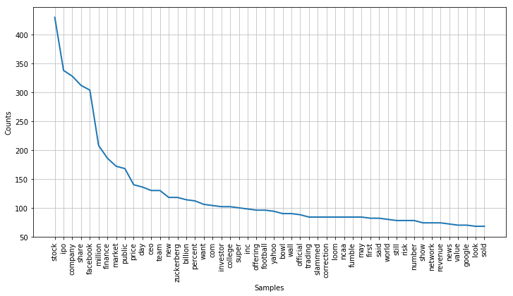

```python
# Word frequency analysis

#finance
plt.figure(figsize=(12,6))
fdist.plot(50)
```

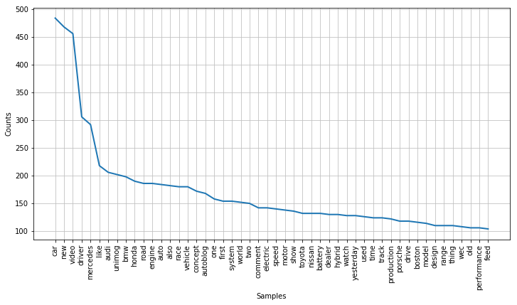

```python
#auto
plt.figure(figsize=(12,6))
gdist.plot(50)
```

## 2. Popular words from each dataset

```python
#top 10 finance data words

#fdist.most_common(10)

freq_word = []

# two values or columns in fdist_a
for k in list(fdist.most_common(10)):
    freq_word.append(k)

#make it like an Excel worksheet
wordlist = pd.DataFrame(freq_word)
wordlist = wordlist.rename(columns={0: 'word', 1: 'freq'})

wordlist.head(10)
```

|  | word | freq |
| --- | --- | --- |
| 0 | stock | 430 |
| 1 | ipo | 338 |
| 2 | company | 328 |
| 3 | share | 312 |
| 4 | facebook | 304 |
| 5 | million | 208 |
| 6 | finance | 186 |
| 7 | market | 172 |
| 8 | public | 168 |
| 9 | price | 140 |

```python
#top 10 auto data words

#gdist.most_common(10)

freq_word1 = []

# two values or columns in fdist_a
for z in list(gdist.most_common(10)):
    freq_word1.append(z)

#make it like an Excel worksheet
wordlist = pd.DataFrame(freq_word1)
wordlist = wordlist.rename(columns={0: 'word', 1: 'freq'})

wordlist.head(10)
```

|  | word | freq |
| --- | --- | --- |
| 0 | car | 484 |
| 1 | new | 468 |
| 2 | video | 456 |
| 3 | driver | 306 |
| 4 | mercedes | 292 |
| 5 | like | 218 |
| 6 | audi | 206 |
| 7 | unimog | 202 |
| 8 | bmw | 198 |
| 9 | honda | 190 |

```python
# # Word frequency analysis using bi-grams

tokens = str(fin)
#lowecases
tokens = tokens.lower()
# Remove useless numbers and alphanumerical words
tokens = re.sub("[^a-zA-Z0-9]", " ", tokens)
#tokenization or word split
tokens = word_tokenize(tokens)
#get stemming words or lemmas
wordnet_lemmatizer = WordNetLemmatizer()
tokens = (wordnet_lemmatizer.lemmatize(word) for word in tokens)
#additional stopwrods
more_stopwords = set(('cant', 'getting', 'mbrace', 'aint', 'today','report', 'permalink', 'ago', 'hour', 'year', 'abuse', 'see', 'get'))
extra_stoplist = set(stopwords.words('english')) | more_stopwords
tokens = (word for word in tokens if word not in extra_stoplist)
# Filter non-alphanumeric characters from tokens
tokens = (word for word in tokens if word.isalpha())
#remove short words
tokens = (word for word in tokens if len(word) >= 3)
#Create your bigrams ... a bigram are a pair of two tokens
bigrams = nltk.bigrams(tokens)
fdist_b = nltk.FreqDist(bigrams)
fdist_b
```

```
FreqDist({('college', 'football'): 96, ('super', 'bowl'): 90, ('stock', 'slammed'): 84, ('slammed', 'official'): 84, ('official', 'correction'): 84, ('correction', 'loom'): 84, ('ncaa', 'fumble'): 84, ('fumble', 'college'): 84, ('football', 'team'): 84, ('team', 'want'): 84, ...})
```

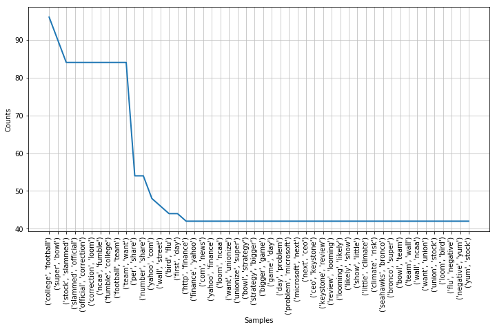

```python
plt.figure(figsize=(12,6))
fdist_b.plot(50)
```

```python
tokens = str(gin)
#lowecases
tokens = tokens.lower()
# Remove useless numbers and alphanumerical words
tokens = re.sub("[^a-zA-Z0-9]", " ", tokens)
#tokenization or word split
tokens = word_tokenize(tokens)
#get stemming words or lemmas
wordnet_lemmatizer = WordNetLemmatizer()
tokens = (wordnet_lemmatizer.lemmatize(word) for word in tokens)
#additional stopwrods
more_stopwords = set(('cant', 'getting', 'mbrace', 'aint', 'today','report', 'permalink', 'ago', 'hour', 'year', 'abuse', 'see', 'get'))
extra_stoplist = set(stopwords.words('english')) | more_stopwords
tokens = (word for word in tokens if word not in extra_stoplist)
# Filter non-alphanumeric characters from tokens
tokens = (word for word in tokens if word.isalpha())
#remove short words
tokens = (word for word in tokens if len(word) >= 3)
#Create your bigrams ... a bigram are a pair of two tokens
bigrams = nltk.bigrams(tokens)
gdist_b = nltk.FreqDist(bigrams)
gdist_b
```

```
FreqDist({('mercedes', 'benz'): 88, ('new', 'york'): 86, ('roll', 'royce'): 80, ('royce', 'ghost'): 80, ('ghost', 'nip'): 80, ('nip', 'tuck'): 80, ('nissan', 'pathfinder'): 72, ('bmw', 'driver'): 68, ('tron', 'quattro'): 64, ('beverly', 'hill'): 62, ...})
```

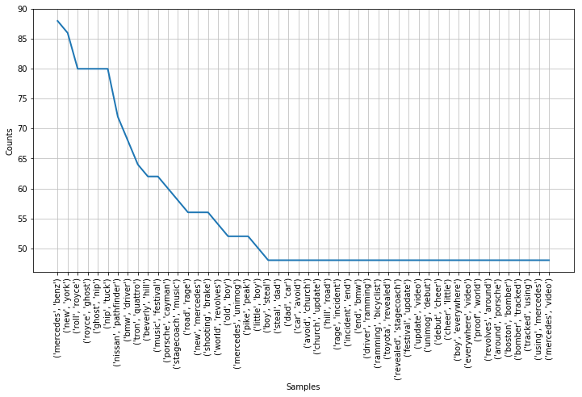

```python
plt.figure(figsize=(12,6))
gdist_b.plot(50)
```

## 3. Popular bi-grams from each dataset

```python
#Top 10 finance data bigrams
fdist_b.most_common(10)
```

```
[(('college', 'football'), 96),
 (('super', 'bowl'), 90),
 (('stock', 'slammed'), 84),
 (('slammed', 'official'), 84),
 (('official', 'correction'), 84),
 (('correction', 'loom'), 84),
 (('ncaa', 'fumble'), 84),
 (('fumble', 'college'), 84),
 (('football', 'team'), 84),
 (('team', 'want'), 84)]
```

```python
#Top 10 auto data bigrams
gdist_b.most_common(10)
```

```
[(('mercedes', 'benz'), 88),
 (('new', 'york'), 86),
 (('roll', 'royce'), 80),
 (('royce', 'ghost'), 80),
 (('ghost', 'nip'), 80),
 (('nip', 'tuck'), 80),
 (('nissan', 'pathfinder'), 72),
 (('bmw', 'driver'), 68),
 (('tron', 'quattro'), 64),
 (('beverly', 'hill'), 62)]
```

## 4. A separate word cloud for each data using a mask image (auto vs. finance). The size of word cloud should be large enough for comparison (figsize=(16,16)). Make sure to remove stopwords.

```
(-0.5, 242.5, 207.5, -0.5)
```

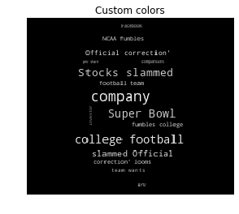

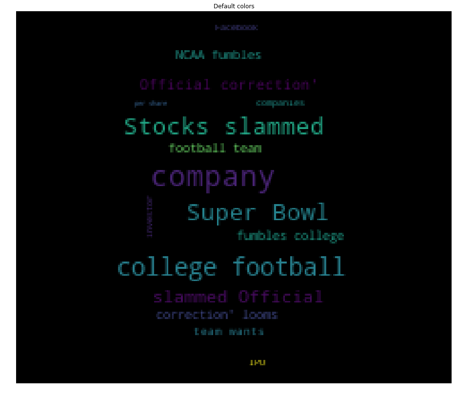

```python
#finance data word cloud


import numpy as np
from PIL import Image
from os import path
import matplotlib.pyplot as plt
import random
from wordcloud import WordCloud, STOPWORDS


def grey_color_func(word, font_size, position, orientation, random_state=None, **kwargs):
    return "hsl(0, 0%%, %d%%)" % random.randint(60, 100)

# Read the whole text.
text = open('data/finance.csv').read()

# read the mask image
# taken from
# http://www.stencilry.org/stencils/movies/star%20wars/storm-trooper.gif

mask = np.array(Image.open("data/dollar.jpg"))

# movie script of "a new hope"
# http://www.imsdb.com/scripts/Star-Wars-A-New-Hope.html
# May the lawyers deem this fair use.
#text = open("a_new_hope.txt").read()

# preprocessing the text a little bit
#text = text.replace("HAN", "Han")
#text = text.replace("LUKE'S", "Luke")

# adding movie script specific stopwords
stopwords = set(STOPWORDS)
stopwords.add("will")
stopwords.add("going")
stopwords.add("cant")
stopwords.add("getting")
stopwords.add("must")
stopwords.add("mbrace")
stopwords.add("aint")
stopwords.add("today")
stopwords.add("report")
stopwords.add("permalink")
stopwords.add("ago")
stopwords.add("hour")
stopwords.add("year")
stopwords.add("abuse")
stopwords.add("see")
stopwords.add("get")

wc = WordCloud(max_words=1000, mask=mask, stopwords=stopwords, margin=10,
               random_state=1).generate(text)
# store default colored image
default_colors = wc.to_array()
plt.title("Custom colors")
plt.imshow(wc.recolor(color_func=grey_color_func, random_state=3))
wc.to_file("car1.png")
plt.axis("off")

plt.figure(figsize=(16,16))
plt.title("Default colors")
plt.imshow(default_colors)
plt.axis("off")
```

```
(-0.5, 1635.5, 763.5, -0.5)
```

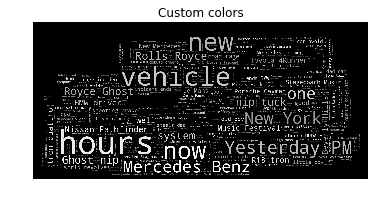

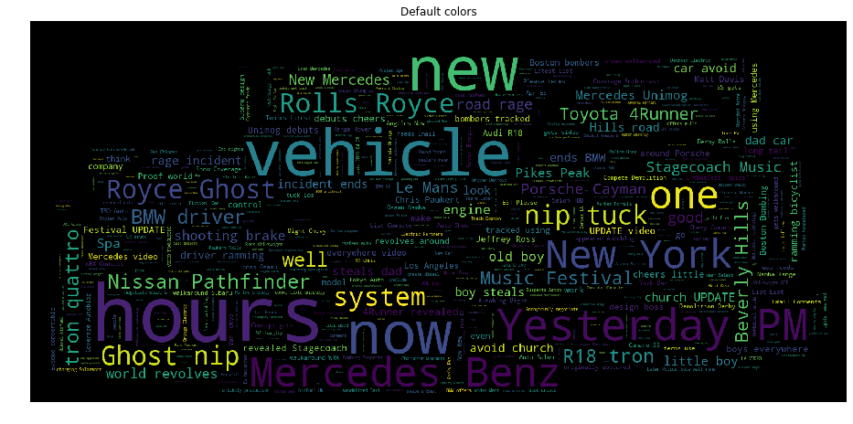

```python
#auto data word cloud

import numpy as np
from PIL import Image
from os import path
import matplotlib.pyplot as plt
import random
from wordcloud import WordCloud, STOPWORDS


def grey_color_func(word, font_size, position, orientation, random_state=None, **kwargs):
    return "hsl(0, 0%%, %d%%)" % random.randint(60, 100)

# Read the whole text.
text = open('data/auto.csv').read()

# read the mask image
# taken from
# http://www.stencilry.org/stencils/movies/star%20wars/storm-trooper.gif

mask = np.array(Image.open("data/car3.png"))

# movie script of "a new hope"
# http://www.imsdb.com/scripts/Star-Wars-A-New-Hope.html
# May the lawyers deem this fair use.
#text = open("a_new_hope.txt").read()

# preprocessing the text a little bit
#text = text.replace("HAN", "Han")
#text = text.replace("LUKE'S", "Luke")

# adding movie script specific stopwords
stopwords = set(STOPWORDS)
stopwords.add("will")
stopwords.add("going")
stopwords.add("cant")
stopwords.add("getting")
stopwords.add("must")
stopwords.add("mbrace")
stopwords.add("aint")
stopwords.add("today")
stopwords.add("report")
stopwords.add("permalink")
stopwords.add("ago")
stopwords.add("hour")
stopwords.add("year")
stopwords.add("abuse")
stopwords.add("see")
stopwords.add("get")

wc = WordCloud(max_words=1000, mask=mask, stopwords=stopwords, margin=10,
               random_state=1).generate(text)
# store default colored image
default_colors = wc.to_array()
plt.title("Custom colors")
plt.imshow(wc.recolor(color_func=grey_color_func, random_state=3))
wc.to_file("car1.png")
plt.axis("off")

plt.figure(figsize=(16,16))
plt.title("Default colors")
plt.imshow(default_colors)
plt.axis("off")
```

## 5. The results of testing your hypotheses

Accept the null hypithesis, indicating that some of the most common words in 'auto' data was car names, and the most common words in 'finance' were related to financial topics.

I found the most common bigrams for the finance data to be very surprising as most of the top bigrams were regarding sports such as football and the super bowl

## 6. Explain the following concepts and methods and why they are needed (You must use YOUR OWN WORDS to answer the following terms. Copying texts from the lecture note/the Internet is strictly prohibited)

a) This is important because real-world data is unstructured and needs to be cleaned in order to perform analytics on the data

b) This is the method of breaking down sentences or strings of data into managable and manipulatable pieces or 'tokens'

c) These are words that are essentially useless as they hold no deeper meaning

d) This is a method of transforming all the data in a dataset to lowercase in order to easier manipulate the data

f) This is the method of reducing a word to its word stem by removing prefixes or suffixes to a word